# Kostikey (Gus) Mustakas

## Pablo Rivas, CMPT 404

## HW05: K-Means Color Quantization and Multilayered Perceptron

## Problem Set

The following is a list of problems you will work on. When providing your solutions (hopefully using LATEX), do not simply give the final answer, show how you arrived to the solution, justify your assumptions, and explain your results clearly.

**1. Experiment with k-means for color quantization**

Using sklearn’s implementation of k-means, find the best color clustering for an image of your choice. A good portrait of yourself could be fun (just sayin’). Color quantization is the science behind compression of images. The idea is to represent an image with fewer colors than the original. The experiment consists of the following steps:

(a) Download to your computer the file http://reev.us/cmpt404f16/hw/hw5.kmeans.img.py

```
# Modified by: Pablo Rivas <Pablo.Rivas@Marist.edu>
# on Nov/3/2016
# Original Code:
# http://scikit-learn.org/stable/_downloads/plot_color_quantization.py
# Original Authors:
#          Robert Layton <robertlayton@gmail.com>
#          Olivier Grisel <olivier.grisel@ensta.org>
#          Mathieu Blondel <mathieu@mblondel.org>
#
# License: BSD 3 clause

print(__doc__)
from scipy import misc
import numpy as np
import matplotlib.pyplot as plt
from sklearn.cluster import KMeans
from sklearn.metrics import pairwise_distances_argmin
from sklearn.datasets import load_sample_image
from sklearn.utils import shuffle
from time import time

# Specify the number of colors here
n_colors = 2

# Load your photo here
img = misc.imread('myPic.jpg')

# Convert to floats instead of the default 8 bits integer coding. Dividing by
# 255 is important so that plt.imshow behaves works well on float data (need to
# be in the range [0-1])
img = np.array(img, dtype=np.float64) / 255

# Load Image and transform to a 2D numpy array.
w, h, d = original_shape = tuple(img.shape)
assert d == 3
image_array = np.reshape(img, (w * h, d))

print("Fitting model on a small sub-sample of the data")
t0 = time()
image_array_sample = shuffle(image_array, random_state=0)[:1000]
kmeans = KMeans(n_clusters=n_colors, random_state=0).fit(image_array_sample)
print("done in %0.3fs." % (time() - t0))

# Get labels for all points
print("Predicting color indices on the full image (k-means)")
t0 = time()
labels = kmeans.predict(image_array)
print("done in %0.3fs." % (time() - t0))

def recreate_image(codebook, labels, w, h):
    """Recreate the (compressed) image from the code book & labels"""
    d = codebook.shape[1]
    image = np.zeros((w, h, d))
    label_idx = 0
    for i in range(w):
        for j in range(h):
            image[i][j] = codebook[labels[label_idx]]
            label_idx += 1
    return image

# Display all results, alongside original image
plt.figure(1)
plt.clf()
ax = plt.axes([0, 0, 1, 1])
plt.axis('off')
plt.title('Original image (96,615 colors)')
plt.imshow(img)

plt.figure(2)
plt.clf()
ax = plt.axes([0, 0, 1, 1])
plt.axis('off')
plt.title('Quantized image (64 colors, K-Means)')
plt.imshow(recreate_image(kmeans.cluster_centers_, labels, w, h))

plt.show()
```

```python
(b) In the same folder where you downloaded the program, save a copy of your picture for experi-
mentation.
```

**Uncomment at end**

(c) Go to line 23 and set n colors with your choice of a number of colors between 2 and 64. This number is actually the number of clusters (or k) we are searching for in an unsupervised manner using k-means.

**Bald Trump: n_colors = 5**

```
Automatically created module for IPython interactive environment
Fitting model on a small sub-sample of the data
done in 0.161s.
Predicting color indices on the full image (k-means)
done in 0.017s.
```

[figure not shown]

[figure not shown]

```python
# Modified by: Pablo Rivas <Pablo.Rivas@Marist.edu>
# on Nov/3/2016
# Original Code:
# http://scikit-learn.org/stable/_downloads/plot_color_quantization.py
# Original Authors:
#          Robert Layton <robertlayton@gmail.com>
#          Olivier Grisel <olivier.grisel@ensta.org>
#          Mathieu Blondel <mathieu@mblondel.org>
#
# License: BSD 3 clause

print(__doc__)
from scipy import misc
import numpy as np
import matplotlib.pyplot as plt
from sklearn.cluster import KMeans
from sklearn.metrics import pairwise_distances_argmin
from sklearn.datasets import load_sample_image
from sklearn.utils import shuffle
from time import time

# Specify the number of colors here
n_colors = 5

# Load your photo here
img = misc.imread('trump.jpeg')

# Convert to floats instead of the default 8 bits integer coding. Dividing by
# 255 is important so that plt.imshow behaves works well on float data (need to
# be in the range [0-1])
img = np.array(img, dtype=np.float64) / 255

# Load Image and transform to a 2D numpy array.
w, h, d = original_shape = tuple(img.shape)
assert d == 3
image_array = np.reshape(img, (w * h, d))

print("Fitting model on a small sub-sample of the data")
t0 = time()
image_array_sample = shuffle(image_array, random_state=0)[:1000]
kmeans = KMeans(n_clusters=n_colors, random_state=0).fit(image_array_sample)
print("done in %0.3fs." % (time() - t0))

# Get labels for all points
print("Predicting color indices on the full image (k-means)")
t0 = time()
labels = kmeans.predict(image_array)
print("done in %0.3fs." % (time() - t0))

def recreate_image(codebook, labels, w, h):
    """Recreate the (compressed) image from the code book & labels"""
    d = codebook.shape[1]
    image = np.zeros((w, h, d))
    label_idx = 0
    for i in range(w):
        for j in range(h):
            image[i][j] = codebook[labels[label_idx]]
            label_idx += 1
    return image

# Display all results, alongside original image
plt.figure(1)
plt.clf()
ax = plt.axes([0, 0, 1, 1])
plt.axis('off')
plt.title('Original image (96,615 colors)')
plt.imshow(img)

plt.figure(2)
plt.clf()
ax = plt.axes([0, 0, 1, 1])
plt.axis('off')
plt.title('Quantized image (64 colors, K-Means)')
plt.imshow(recreate_image(kmeans.cluster_centers_, labels, w, h))

plt.show()
```

**Parrot: n_colors=8**

```
Automatically created module for IPython interactive environment
Fitting model on a small sub-sample of the data
done in 0.058s.
Predicting color indices on the full image (k-means)
done in 0.022s.
```

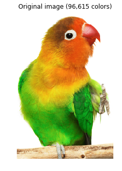

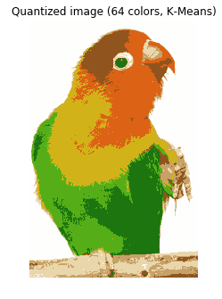

```python
# Modified by: Pablo Rivas <Pablo.Rivas@Marist.edu>
# on Nov/3/2016
# Original Code:
# http://scikit-learn.org/stable/_downloads/plot_color_quantization.py
# Original Authors:
#          Robert Layton <robertlayton@gmail.com>
#          Olivier Grisel <olivier.grisel@ensta.org>
#          Mathieu Blondel <mathieu@mblondel.org>
#
# License: BSD 3 clause

print(__doc__)
from scipy import misc
import numpy as np
import matplotlib.pyplot as plt
from sklearn.cluster import KMeans
from sklearn.metrics import pairwise_distances_argmin
from sklearn.datasets import load_sample_image
from sklearn.utils import shuffle
from time import time

# Specify the number of colors here
n_colors = 8

# Load your photo here
img = misc.imread('bird.jpg')

# Convert to floats instead of the default 8 bits integer coding. Dividing by
# 255 is important so that plt.imshow behaves works well on float data (need to
# be in the range [0-1])
img = np.array(img, dtype=np.float64) / 255

# Load Image and transform to a 2D numpy array.
w, h, d = original_shape = tuple(img.shape)
assert d == 3
image_array = np.reshape(img, (w * h, d))

print("Fitting model on a small sub-sample of the data")
t0 = time()
image_array_sample = shuffle(image_array, random_state=0)[:1000]
kmeans = KMeans(n_clusters=n_colors, random_state=0).fit(image_array_sample)
print("done in %0.3fs." % (time() - t0))

# Get labels for all points
print("Predicting color indices on the full image (k-means)")
t0 = time()
labels = kmeans.predict(image_array)
print("done in %0.3fs." % (time() - t0))

def recreate_image(codebook, labels, w, h):
    """Recreate the (compressed) image from the code book & labels"""
    d = codebook.shape[1]
    image = np.zeros((w, h, d))
    label_idx = 0
    for i in range(w):
        for j in range(h):
            image[i][j] = codebook[labels[label_idx]]
            label_idx += 1
    return image

# Display all results, alongside original image
plt.figure(1)
plt.clf()
ax = plt.axes([0, 0, 1, 1])
plt.axis('off')
plt.title('Original image (96,615 colors)')
plt.imshow(img)

plt.figure(2)
plt.clf()
ax = plt.axes([0, 0, 1, 1])
plt.axis('off')
plt.title('Quantized image (64 colors, K-Means)')
plt.imshow(recreate_image(kmeans.cluster_centers_, labels, w, h))

plt.show()
```

(d) Then go to line 25 and replace the image file name with the name of your image file. This is where your image is read into a numpy array.

**n_colors=3**

```
Automatically created module for IPython interactive environment
```

```
Fitting model on a small sub-sample of the data
done in 0.400s.
Predicting color indices on the full image (k-means)
done in 1.575s.
```

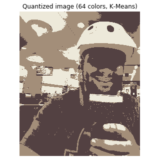

```python
# Modified by: Pablo Rivas <Pablo.Rivas@Marist.edu>
# on Nov/3/2016
# Original Code:
# http://scikit-learn.org/stable/_downloads/plot_color_quantization.py
# Original Authors:
#          Robert Layton <robertlayton@gmail.com>
#          Olivier Grisel <olivier.grisel@ensta.org>
#          Mathieu Blondel <mathieu@mblondel.org>
#
# License: BSD 3 clause

print(__doc__)
from scipy import misc
import numpy as np
import matplotlib.pyplot as plt
from sklearn.cluster import KMeans
from sklearn.metrics import pairwise_distances_argmin
from sklearn.datasets import load_sample_image
from sklearn.utils import shuffle
from time import time

# Specify the number of colors here
n_colors = 3

# Load your photo here
img = misc.imread('myPic1.jpg')

# Convert to floats instead of the default 8 bits integer coding. Dividing by
# 255 is important so that plt.imshow behaves works well on float data (need to
# be in the range [0-1])
img = np.array(img, dtype=np.float64) / 255

# Load Image and transform to a 2D numpy array.
w, h, d = original_shape = tuple(img.shape)
assert d == 3
image_array = np.reshape(img, (w * h, d))

print("Fitting model on a small sub-sample of the data")
t0 = time()
image_array_sample = shuffle(image_array, random_state=0)[:1000]
kmeans = KMeans(n_clusters=n_colors, random_state=0).fit(image_array_sample)
print("done in %0.3fs." % (time() - t0))

# Get labels for all points
print("Predicting color indices on the full image (k-means)")
t0 = time()
labels = kmeans.predict(image_array)
print("done in %0.3fs." % (time() - t0))

def recreate_image(codebook, labels, w, h):
    """Recreate the (compressed) image from the code book & labels"""
    d = codebook.shape[1]
    image = np.zeros((w, h, d))
    label_idx = 0
    for i in range(w):
        for j in range(h):
            image[i][j] = codebook[labels[label_idx]]
            label_idx += 1
    return image

# Display all results, alongside original image
plt.figure(1)
plt.clf()
ax = plt.axes([0, 0, 1, 1])
plt.axis('off')
plt.title('Original image (96,615 colors)')
plt.imshow(img)

plt.figure(2)
plt.clf()
ax = plt.axes([0, 0, 1, 1])
plt.axis('off')
plt.title('Quantized image (64 colors, K-Means)')
plt.imshow(recreate_image(kmeans.cluster_centers_, labels, w, h))

plt.show()
```

**n_colors=6**

```
Automatically created module for IPython interactive environment
Fitting model on a small sub-sample of the data
```

```
done in 0.447s.
Predicting color indices on the full image (k-means)
done in 1.678s.
```

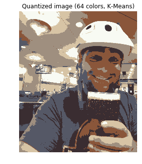

```python
# Modified by: Pablo Rivas <Pablo.Rivas@Marist.edu>
# on Nov/3/2016
# Original Code:
# http://scikit-learn.org/stable/_downloads/plot_color_quantization.py
# Original Authors:
#          Robert Layton <robertlayton@gmail.com>
#          Olivier Grisel <olivier.grisel@ensta.org>
#          Mathieu Blondel <mathieu@mblondel.org>
#
# License: BSD 3 clause

print(__doc__)
from scipy import misc
import numpy as np
import matplotlib.pyplot as plt
from sklearn.cluster import KMeans
from sklearn.metrics import pairwise_distances_argmin
from sklearn.datasets import load_sample_image
from sklearn.utils import shuffle
from time import time

# Specify the number of colors here
n_colors = 6

# Load your photo here
img = misc.imread('myPic1.jpg')

# Convert to floats instead of the default 8 bits integer coding. Dividing by
# 255 is important so that plt.imshow behaves works well on float data (need to
# be in the range [0-1])
img = np.array(img, dtype=np.float64) / 255

# Load Image and transform to a 2D numpy array.
w, h, d = original_shape = tuple(img.shape)
assert d == 3
image_array = np.reshape(img, (w * h, d))

print("Fitting model on a small sub-sample of the data")
t0 = time()
image_array_sample = shuffle(image_array, random_state=0)[:1000]
kmeans = KMeans(n_clusters=n_colors, random_state=0).fit(image_array_sample)
print("done in %0.3fs." % (time() - t0))

# Get labels for all points
print("Predicting color indices on the full image (k-means)")
t0 = time()
labels = kmeans.predict(image_array)
print("done in %0.3fs." % (time() - t0))

def recreate_image(codebook, labels, w, h):
    """Recreate the (compressed) image from the code book & labels"""
    d = codebook.shape[1]
    image = np.zeros((w, h, d))
    label_idx = 0
    for i in range(w):
        for j in range(h):
            image[i][j] = codebook[labels[label_idx]]
            label_idx += 1
    return image

# Display all results, alongside original image
plt.figure(1)
plt.clf()
ax = plt.axes([0, 0, 1, 1])
plt.axis('off')
plt.title('Original image (96,615 colors)')
plt.imshow(img)

plt.figure(2)
plt.clf()
ax = plt.axes([0, 0, 1, 1])
plt.axis('off')
plt.title('Quantized image (64 colors, K-Means)')
plt.imshow(recreate_image(kmeans.cluster_centers_, labels, w, h))

plt.show()
```

**n_colors=26**

```
Automatically created module for IPython interactive environment
Fitting model on a small sub-sample of the data
```

```
done in 0.497s.
Predicting color indices on the full image (k-means)
done in 2.567s.
```

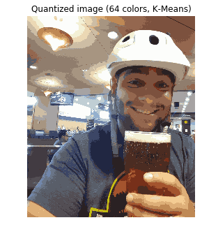

```python
# Modified by: Pablo Rivas <Pablo.Rivas@Marist.edu>
# on Nov/3/2016
# Original Code:
# http://scikit-learn.org/stable/_downloads/plot_color_quantization.py
# Original Authors:
#          Robert Layton <robertlayton@gmail.com>
#          Olivier Grisel <olivier.grisel@ensta.org>
#          Mathieu Blondel <mathieu@mblondel.org>
#
# License: BSD 3 clause

print(__doc__)
from scipy import misc
import numpy as np
import matplotlib.pyplot as plt
from sklearn.cluster import KMeans
from sklearn.metrics import pairwise_distances_argmin
from sklearn.datasets import load_sample_image
from sklearn.utils import shuffle
from time import time

# Specify the number of colors here
n_colors = 26

# Load your photo here
img = misc.imread('myPic1.jpg')

# Convert to floats instead of the default 8 bits integer coding. Dividing by
# 255 is important so that plt.imshow behaves works well on float data (need to
# be in the range [0-1])
img = np.array(img, dtype=np.float64) / 255

# Load Image and transform to a 2D numpy array.
w, h, d = original_shape = tuple(img.shape)
assert d == 3
image_array = np.reshape(img, (w * h, d))

print("Fitting model on a small sub-sample of the data")
t0 = time()
image_array_sample = shuffle(image_array, random_state=0)[:1000]
kmeans = KMeans(n_clusters=n_colors, random_state=0).fit(image_array_sample)
print("done in %0.3fs." % (time() - t0))

# Get labels for all points
print("Predicting color indices on the full image (k-means)")
t0 = time()
labels = kmeans.predict(image_array)
print("done in %0.3fs." % (time() - t0))

def recreate_image(codebook, labels, w, h):
    """Recreate the (compressed) image from the code book & labels"""
    d = codebook.shape[1]
    image = np.zeros((w, h, d))
    label_idx = 0
    for i in range(w):
        for j in range(h):
            image[i][j] = codebook[labels[label_idx]]
            label_idx += 1
    return image

# Display all results, alongside original image
plt.figure(1)
plt.clf()
ax = plt.axes([0, 0, 1, 1])
plt.axis('off')
plt.title('Original image (96,615 colors)')
plt.imshow(img)

plt.figure(2)
plt.clf()
ax = plt.axes([0, 0, 1, 1])
plt.axis('off')
plt.title('Quantized image (64 colors, K-Means)')
plt.imshow(recreate_image(kmeans.cluster_centers_, labels, w, h))

plt.show()
```

(e) Run the program. Observe the result. If the result does not look funny to you, repeat from 1.(c) until it does. Then, report your result image along with your answers to the following questions:

i. Explain... what happens when you increase or decrease the value of n colors?

- As n_colors increases, the number of clusters that the k-means algorithm uses increases. The more clusters used the more colors the algorithm has to to work with when rebuilding the image. This results in for every additionl color used in the reconstruction, the closer the reconstructed image gets to the original image.

ii. Explain... in what other possible applications do you think this can be useful?

- This kind of image manipulation could have many potenial use cases but the first one that comes to mind is an elastic data reduction method for images. Se could reduce image quality to the minimum threshold of colors that allows humans to still process the image visually without issue.
- This could also make for some pretty cool artistic tools for image manipulation.

iii. Why do you think the resulting picture was funny at the end?

- At a point the images became funny looking because the algorithm was limited to a number of colors it could not successfully reconstruct the image with. Features that should in fact have a different color were forced to resolve with less. This results in the picture being rebuilt in a humorous mannor.

**2. Neural networks: The MLP**

(a) Download the python program http://reev.us/cmpt404f16/hw/hw5.MLP.sol.py which implements a 10-fold cross-validation approach to find the best number of neurons and the best learning parameter $\eta$ (eta) in an MLP for regression. For learning purposes you could download http://reev.us/cmpt404f16/hw/hw5.MLP.py first, which is a simple implementation of the MLP.

```
import hw5gendata
import numpy as np
import matplotlib.pyplot as plt
from sklearn.neural_network import MLPRegressor
from sklearn.model_selection import KFold

# number of samples
N = 1000

# generate data & split it into X (training input) and y (target output)
X, y = hw5gendata.genDataSet(N)

# linear regression solution
w=np.linalg.pinv(X.T.dot(X)).dot(X.T).dot(y)


#neurons  <- number of neurons in the hidden layer
#eta  <- the learning rate parameter

bestNeurons=0
bestEta=0
bestScore=float('-inf')
score=0
for neurons in range(1,101,1):
  for eta in range(1,11,1):
    eta=eta/10.0
    kf = KFold(n_splits=10)
    cvscore=[]
    for train, validation in kf.split(X):
      X_train, X_validation, y_train, y_validation = X[train, :], X[validation, :], y[train], y[validation]
      # here we create the MLP regressor
      mlp =  MLPRegressor(hidden_layer_sizes=(neurons,), verbose=False, learning_rate_init=eta)
      # here we train the MLP
      mlp.fit(X_train, y_train)
      # now we get E_out for validation set
      score=mlp.score(X_validation, y_validation)
      cvscore.append(score)

    # average CV score
    score=sum(cvscore)/len(cvscore)
    if (score > bestScore):
      bestScore=score
      bestNeurons=neurons
      bestEta=eta
      print("Neurons " + str(neurons) + ", eta " + str(eta) + ". Testing set CV score: %f" % score)

# here we get a new training dataset
X, y = hw5gendata.genDataSet(N)
# here we create the final MLP regressor
mlp =  MLPRegressor(hidden_layer_sizes=(bestNeurons,), verbose=True, learning_rate_init=bestEta)
# here we train the final MLP
mlp.fit(X, y)
# E_out in training
print("Training set score: %f" % mlp.score(X, y))
# here we get a new testing dataset
X, y = hw5gendata.genDataSet(N)
# here test the final MLP regressor and get E_out for testing set
ypred=mlp.predict(X)
score=mlp.score(X, y)
print("Testing set score: %f" % score)
plt.plot(X[:, 0], X[:, 1], '.')
plt.plot(X[:, 0], y, 'rx')
plt.plot(X[:, 0], ypred, '-k')
ypredLR=X.dot(w)
plt.plot(X[:, 0], ypredLR, '--g')
plt.show()
```

(b) Download the python program http://reev.us/cmpt404f16/hw/hw5gendata.py which generates random data.

```
import numpy as np
from matplotlib import pyplot as plt

def genDataSet(N):
    x = np.sort(np.random.normal(0, 1, N)*3)
    ytrue = (np.cos(x) + 2) / (np.cos(x * 1.4) + 2)
    noise = np.random.normal(0, 0.2, N)
    y = ytrue + noise
    X = np.c_[x, y]
    return X, ytrue
```

(c) Run the program in 2.(a) for 1,000 samples, and then take note of the best number of neurons and $\eta$. Go here https://goo.gl/forms/QFmaNWYaFLcPWdim2 and report your results. You can do it as many times as you want, but at least one is required.

```
##################################################
##################################################
This iteration has 50 hidden neurons and an eta of 0.1
Iteration 1, loss = 0.52911575
Iteration 2, loss = 0.15094200
Iteration 3, loss = 0.08497470
Iteration 4, loss = 0.05455300
Iteration 5, loss = 0.03432570
Iteration 6, loss = 0.02756493
Iteration 7, loss = 0.02153919
Iteration 8, loss = 0.01915194
Iteration 9, loss = 0.01720384
Iteration 10, loss = 0.01705578
Iteration 11, loss = 0.01527940
Iteration 12, loss = 0.01482355
Iteration 13, loss = 0.01458352
Iteration 14, loss = 0.01411527
Iteration 15, loss = 0.01403822
Iteration 16, loss = 0.01396224
Iteration 17, loss = 0.01365692
Iteration 18, loss = 0.01335822
Iteration 19, loss = 0.01350102
Iteration 20, loss = 0.01311411
Iteration 21, loss = 0.01462588
Iteration 22, loss = 0.01402217
Iteration 23, loss = 0.01394343
Training loss did not improve more than tol=0.000100 for two consecutive epochs. Stopping.
Training set score: 0.865028
Testing set score: 0.866510
```

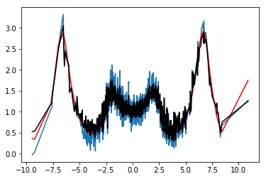

```
##################################################
##################################################
This iteration has 50 hidden neurons and an eta of 0.01
Iteration 1, loss = 0.24324036
Iteration 2, loss = 0.05791034
Iteration 3, loss = 0.04466788
Iteration 4, loss = 0.04348989
Iteration 5, loss = 0.02825803
Iteration 6, loss = 0.01903152
Iteration 7, loss = 0.01903939
Iteration 8, loss = 0.01753823
Iteration 9, loss = 0.01483574
Iteration 10, loss = 0.01440175
Iteration 11, loss = 0.01441415
Iteration 12, loss = 0.01370118
Iteration 13, loss = 0.01363531
Iteration 14, loss = 0.01316585
Iteration 15, loss = 0.01297882
Iteration 16, loss = 0.01274397
Iteration 17, loss = 0.01263389
Iteration 18, loss = 0.01235926
Iteration 19, loss = 0.01223471
Iteration 20, loss = 0.01191264
Iteration 21, loss = 0.01180036
Iteration 22, loss = 0.01178971
Iteration 23, loss = 0.01147358
Iteration 24, loss = 0.01117415
Iteration 25, loss = 0.01105900
Iteration 26, loss = 0.01104714
Iteration 27, loss = 0.01092351
Iteration 28, loss = 0.01055845
Iteration 29, loss = 0.01037179
Iteration 30, loss = 0.01052020
Iteration 31, loss = 0.01040229
Iteration 32, loss = 0.01032012
Training loss did not improve more than tol=0.000100 for two consecutive epochs. Stopping.
Training set score: 0.891316
Testing set score: 0.901986
```

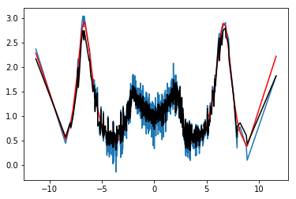

```
##################################################
##################################################
This iteration has 50 hidden neurons and an eta of 0.001
Iteration 1, loss = 1.24161117
Iteration 2, loss = 1.02335545
Iteration 3, loss = 0.83282321
Iteration 4, loss = 0.67212908
Iteration 5, loss = 0.54265541
Iteration 6, loss = 0.43809071
Iteration 7, loss = 0.35967113
Iteration 8, loss = 0.29952966
Iteration 9, loss = 0.25720714
Iteration 10, loss = 0.22589222
Iteration 11, loss = 0.20076333
Iteration 12, loss = 0.18266182
Iteration 13, loss = 0.16638937
Iteration 14, loss = 0.15215117
Iteration 15, loss = 0.13842169
Iteration 16, loss = 0.12592103
Iteration 17, loss = 0.11366926
Iteration 18, loss = 0.10277179
Iteration 19, loss = 0.09226390
Iteration 20, loss = 0.08304701
Iteration 21, loss = 0.07433621
Iteration 22, loss = 0.06660286
Iteration 23, loss = 0.05974814
Iteration 24, loss = 0.05347386
Iteration 25, loss = 0.04802100
Iteration 26, loss = 0.04321208
Iteration 27, loss = 0.03915670
Iteration 28, loss = 0.03566010
Iteration 29, loss = 0.03259081
Iteration 30, loss = 0.02997847
Iteration 31, loss = 0.02776781
Iteration 32, loss = 0.02588881
Iteration 33, loss = 0.02435974
Iteration 34, loss = 0.02300639
Iteration 35, loss = 0.02184893
Iteration 36, loss = 0.02089896
Iteration 37, loss = 0.02002336
```

[output cut: 20 more lines]

```
Iteration 58, loss = 0.01422079
Iteration 59, loss = 0.01409664
Iteration 60, loss = 0.01398403
Iteration 61, loss = 0.01387022
Iteration 62, loss = 0.01374828
Iteration 63, loss = 0.01364755
Iteration 64, loss = 0.01354735
Iteration 65, loss = 0.01345008
Iteration 66, loss = 0.01334733
Iteration 67, loss = 0.01325348
Iteration 68, loss = 0.01315647
Iteration 69, loss = 0.01307989
Training loss did not improve more than tol=0.000100 for two consecutive epochs. Stopping.
Training set score: 0.845535
Testing set score: 0.833661
```

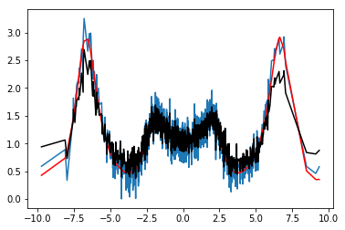

```
##################################################
##################################################
This iteration has 100 hidden neurons and an eta of 0.1
Iteration 1, loss = 1.36299918
Iteration 2, loss = 0.52326614
Iteration 3, loss = 0.17480474
Iteration 4, loss = 0.12170105
Iteration 5, loss = 0.05308749
Iteration 6, loss = 0.03192858
Iteration 7, loss = 0.02926073
Iteration 8, loss = 0.01858481
Iteration 9, loss = 0.02562918
Iteration 10, loss = 0.01804884
Iteration 11, loss = 0.01596493
Iteration 12, loss = 0.01692593
Iteration 13, loss = 0.01608976
Iteration 14, loss = 0.01743213
Training loss did not improve more than tol=0.000100 for two consecutive epochs. Stopping.
Training set score: 0.723236
Testing set score: 0.715352
```

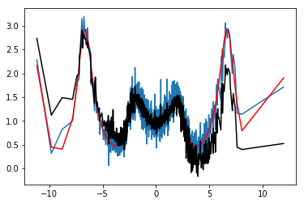

```
##################################################
##################################################
This iteration has 100 hidden neurons and an eta of 0.01
Iteration 1, loss = 0.38937351
Iteration 2, loss = 0.19117904
Iteration 3, loss = 0.05846169
Iteration 4, loss = 0.05947252
Iteration 5, loss = 0.03964411
Iteration 6, loss = 0.03336264
Iteration 7, loss = 0.02639603
Iteration 8, loss = 0.02114979
Iteration 9, loss = 0.01906058
Iteration 10, loss = 0.01608775
Iteration 11, loss = 0.01463855
Iteration 12, loss = 0.01387893
Iteration 13, loss = 0.01356296
Iteration 14, loss = 0.01306814
Iteration 15, loss = 0.01282563
Iteration 16, loss = 0.01272014
Iteration 17, loss = 0.01273923
Iteration 18, loss = 0.01243135
Iteration 19, loss = 0.01220817
Iteration 20, loss = 0.01206770
Iteration 21, loss = 0.01190574
Iteration 22, loss = 0.01180625
Iteration 23, loss = 0.01150996
Iteration 24, loss = 0.01151127
Iteration 25, loss = 0.01133105
Iteration 26, loss = 0.01128957
Iteration 27, loss = 0.01102797
Iteration 28, loss = 0.01099809
Iteration 29, loss = 0.01084915
Iteration 30, loss = 0.01084727
Iteration 31, loss = 0.01082042
Iteration 32, loss = 0.01048256
Iteration 33, loss = 0.01042478
Iteration 34, loss = 0.01045183
Iteration 35, loss = 0.01031555
Iteration 36, loss = 0.01036271
Iteration 37, loss = 0.01032193
Iteration 38, loss = 0.00997687
Iteration 39, loss = 0.00990053
Iteration 40, loss = 0.00981100
Iteration 41, loss = 0.00985164
Training loss did not improve more than tol=0.000100 for two consecutive epochs. Stopping.
Training set score: 0.912552
Testing set score: 0.907573
```

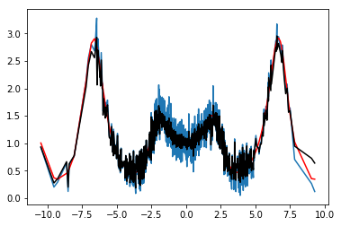

```
##################################################
##################################################
This iteration has 100 hidden neurons and an eta of 0.001
Iteration 1, loss = 0.74746897
Iteration 2, loss = 0.51933427
Iteration 3, loss = 0.36146446
Iteration 4, loss = 0.25359638
Iteration 5, loss = 0.19078974
Iteration 6, loss = 0.15422088
Iteration 7, loss = 0.13119856
Iteration 8, loss = 0.11471126
Iteration 9, loss = 0.10037338
Iteration 10, loss = 0.08700909
Iteration 11, loss = 0.07511324
Iteration 12, loss = 0.06437307
Iteration 13, loss = 0.05516432
Iteration 14, loss = 0.04760993
Iteration 15, loss = 0.04178051
Iteration 16, loss = 0.03719637
Iteration 17, loss = 0.03341243
Iteration 18, loss = 0.03040348
Iteration 19, loss = 0.02805859
Iteration 20, loss = 0.02622751
Iteration 21, loss = 0.02477276
Iteration 22, loss = 0.02359793
Iteration 23, loss = 0.02259349
Iteration 24, loss = 0.02182122
Iteration 25, loss = 0.02107164
Iteration 26, loss = 0.02048071
Iteration 27, loss = 0.01986816
Iteration 28, loss = 0.01932887
Iteration 29, loss = 0.01884223
Iteration 30, loss = 0.01838469
Iteration 31, loss = 0.01799708
Iteration 32, loss = 0.01758536
Iteration 33, loss = 0.01722910
Iteration 34, loss = 0.01687775
Iteration 35, loss = 0.01662097
Iteration 36, loss = 0.01628127
Iteration 37, loss = 0.01598980
```

[output cut: 10 more lines]

```
Iteration 48, loss = 0.01378000
Iteration 49, loss = 0.01365361
Iteration 50, loss = 0.01353907
Iteration 51, loss = 0.01341561
Iteration 52, loss = 0.01333067
Iteration 53, loss = 0.01322570
Iteration 54, loss = 0.01311045
Iteration 55, loss = 0.01305025
Iteration 56, loss = 0.01294755
Iteration 57, loss = 0.01290006
Iteration 58, loss = 0.01282085
Iteration 59, loss = 0.01273424
Training loss did not improve more than tol=0.000100 for two consecutive epochs. Stopping.
Training set score: 0.869420
Testing set score: 0.845667
```

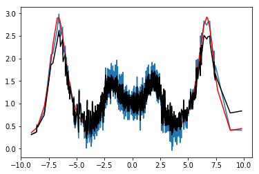

```
##################################################
##################################################
This iteration has 200 hidden neurons and an eta of 0.1
Iteration 1, loss = 5.03328531
Iteration 2, loss = 0.54641200
Iteration 3, loss = 0.39447871
Iteration 4, loss = 0.28470488
Iteration 5, loss = 0.26023105
Iteration 6, loss = 0.16728941
Iteration 7, loss = 0.10572972
Iteration 8, loss = 0.09024661
Iteration 9, loss = 0.08147394
Iteration 10, loss = 0.06332959
Iteration 11, loss = 0.04928545
Iteration 12, loss = 0.05107836
Iteration 13, loss = 0.05644586
Iteration 14, loss = 0.03493409
Iteration 15, loss = 0.02717076
Iteration 16, loss = 0.01746425
Iteration 17, loss = 0.01437765
Iteration 18, loss = 0.01127147
Iteration 19, loss = 0.01024594
Iteration 20, loss = 0.01009023
Iteration 21, loss = 0.00872329
Iteration 22, loss = 0.00861568
Iteration 23, loss = 0.00843031
Iteration 24, loss = 0.00823601
Iteration 25, loss = 0.00844758
Iteration 26, loss = 0.00938995
Iteration 27, loss = 0.00845940
Training loss did not improve more than tol=0.000100 for two consecutive epochs. Stopping.
Training set score: 0.904966
Testing set score: 0.904980
```

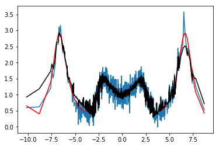

```
##################################################
##################################################
This iteration has 200 hidden neurons and an eta of 0.01
Iteration 1, loss = 0.48199799
Iteration 2, loss = 0.18471912
Iteration 3, loss = 0.05695765
Iteration 4, loss = 0.05128366
Iteration 5, loss = 0.03552764
Iteration 6, loss = 0.02639102
Iteration 7, loss = 0.02076848
Iteration 8, loss = 0.01907673
Iteration 9, loss = 0.01744750
Iteration 10, loss = 0.01546509
Iteration 11, loss = 0.01517543
Iteration 12, loss = 0.01489637
Iteration 13, loss = 0.01432134
Iteration 14, loss = 0.01387735
Iteration 15, loss = 0.01377563
Iteration 16, loss = 0.01353590
Iteration 17, loss = 0.01347582
Iteration 18, loss = 0.01365571
Iteration 19, loss = 0.01339835
Training loss did not improve more than tol=0.000100 for two consecutive epochs. Stopping.
Training set score: 0.848999
Testing set score: 0.859334
```

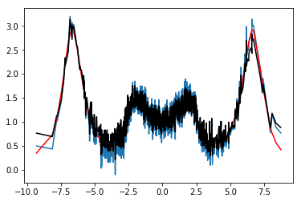

```
##################################################
##################################################
This iteration has 200 hidden neurons and an eta of 0.001
Iteration 1, loss = 0.65626961
Iteration 2, loss = 0.40134490
Iteration 3, loss = 0.25856104
Iteration 4, loss = 0.18900420
Iteration 5, loss = 0.16003960
Iteration 6, loss = 0.14134218
Iteration 7, loss = 0.11793391
Iteration 8, loss = 0.09368021
Iteration 9, loss = 0.07236216
Iteration 10, loss = 0.05692755
Iteration 11, loss = 0.04532972
Iteration 12, loss = 0.03664270
Iteration 13, loss = 0.03009738
Iteration 14, loss = 0.02528208
Iteration 15, loss = 0.02203349
Iteration 16, loss = 0.02011052
Iteration 17, loss = 0.01882926
Iteration 18, loss = 0.01794727
Iteration 19, loss = 0.01736332
Iteration 20, loss = 0.01683098
Iteration 21, loss = 0.01637596
Iteration 22, loss = 0.01595216
Iteration 23, loss = 0.01554377
Iteration 24, loss = 0.01521307
Iteration 25, loss = 0.01485215
Iteration 26, loss = 0.01450269
Iteration 27, loss = 0.01421167
Iteration 28, loss = 0.01394201
Iteration 29, loss = 0.01369585
Iteration 30, loss = 0.01347788
Iteration 31, loss = 0.01331332
Iteration 32, loss = 0.01307618
Iteration 33, loss = 0.01292315
Iteration 34, loss = 0.01275108
Iteration 35, loss = 0.01264040
Iteration 36, loss = 0.01248903
Iteration 37, loss = 0.01239799
Iteration 38, loss = 0.01228836
Iteration 39, loss = 0.01217793
Iteration 40, loss = 0.01210424
Iteration 41, loss = 0.01199187
Iteration 42, loss = 0.01192462
Iteration 43, loss = 0.01185566
Iteration 44, loss = 0.01176139
Training loss did not improve more than tol=0.000100 for two consecutive epochs. Stopping.
Training set score: 0.873340
Testing set score: 0.851747
```

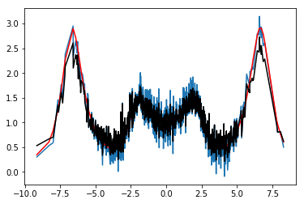

```
##################################################
##################################################
This iteration has 500 hidden neurons and an eta of 0.1
Iteration 1, loss = 17.61881106
Iteration 2, loss = 1.28383155
Iteration 3, loss = 1.43876636
Iteration 4, loss = 2.43851895
Iteration 5, loss = 1.39772921
Training loss did not improve more than tol=0.000100 for two consecutive epochs. Stopping.
Training set score: -9.771804
Testing set score: -8.835044
```

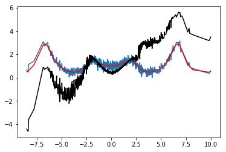

```
##################################################
##################################################
This iteration has 500 hidden neurons and an eta of 0.01
Iteration 1, loss = 0.46142254
Iteration 2, loss = 0.09850525
Iteration 3, loss = 0.07570126
Iteration 4, loss = 0.04195829
Iteration 5, loss = 0.02830085
Iteration 6, loss = 0.02724728
Iteration 7, loss = 0.01974195
Iteration 8, loss = 0.01847213
Iteration 9, loss = 0.01498225
Iteration 10, loss = 0.01526718
Iteration 11, loss = 0.01441956
Iteration 12, loss = 0.01384309
Iteration 13, loss = 0.01364681
Iteration 14, loss = 0.01320662
Iteration 15, loss = 0.01289291
Iteration 16, loss = 0.01299573
Iteration 17, loss = 0.01268814
Iteration 18, loss = 0.01256632
Iteration 19, loss = 0.01243062
Iteration 20, loss = 0.01224705
Iteration 21, loss = 0.01201611
Iteration 22, loss = 0.01180915
Iteration 23, loss = 0.01183046
Iteration 24, loss = 0.01173857
Iteration 25, loss = 0.01172525
Training loss did not improve more than tol=0.000100 for two consecutive epochs. Stopping.
Training set score: 0.873309
Testing set score: 0.843590
```

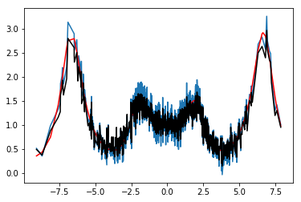

```
##################################################
##################################################
This iteration has 500 hidden neurons and an eta of 0.001
Iteration 1, loss = 0.48979872
Iteration 2, loss = 0.24666770
Iteration 3, loss = 0.16887264
Iteration 4, loss = 0.13743883
Iteration 5, loss = 0.09752322
Iteration 6, loss = 0.05807245
Iteration 7, loss = 0.03555211
Iteration 8, loss = 0.02627765
Iteration 9, loss = 0.02169527
Iteration 10, loss = 0.01867908
Iteration 11, loss = 0.01876213
Iteration 12, loss = 0.01870015
Iteration 13, loss = 0.01759381
Iteration 14, loss = 0.01689909
Iteration 15, loss = 0.01621674
Iteration 16, loss = 0.01561710
Iteration 17, loss = 0.01534827
Iteration 18, loss = 0.01502376
Iteration 19, loss = 0.01473552
Iteration 20, loss = 0.01450666
Iteration 21, loss = 0.01430842
Iteration 22, loss = 0.01409658
Iteration 23, loss = 0.01396350
Iteration 24, loss = 0.01379423
Iteration 25, loss = 0.01365422
Iteration 26, loss = 0.01350008
Iteration 27, loss = 0.01337275
Iteration 28, loss = 0.01332248
Iteration 29, loss = 0.01325226
Iteration 30, loss = 0.01307978
Iteration 31, loss = 0.01298579
Iteration 32, loss = 0.01287920
Iteration 33, loss = 0.01280820
Iteration 34, loss = 0.01271021
Iteration 35, loss = 0.01264011
Training loss did not improve more than tol=0.000100 for two consecutive epochs. Stopping.
Training set score: 0.844436
Testing set score: 0.843756
```

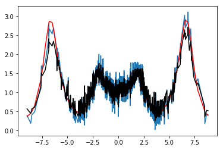

```
##################################################
##################################################
This iteration has 1000 hidden neurons and an eta of 0.1
Iteration 1, loss = 46.72726650
Iteration 2, loss = 6.06031080
Iteration 3, loss = 5.46413654
Iteration 4, loss = 2.67255232
Iteration 5, loss = 2.88881616
Iteration 6, loss = 2.92713768
Iteration 7, loss = 2.09424808
Iteration 8, loss = 1.12642907
Iteration 9, loss = 1.63687163
Iteration 10, loss = 0.76457072
Iteration 11, loss = 0.76811162
Iteration 12, loss = 0.48942711
Iteration 13, loss = 0.19109010
Iteration 14, loss = 0.14137982
Iteration 15, loss = 0.07730235
Iteration 16, loss = 0.08176345
Iteration 17, loss = 0.19827686
Iteration 18, loss = 0.19134355
Training loss did not improve more than tol=0.000100 for two consecutive epochs. Stopping.
Training set score: -0.187130
Testing set score: 0.033717
```

[3 more figures not shown]

```python
import hw5gendata
import numpy as np
import pandas as pd
import matplotlib.pyplot as plt
from sklearn.neural_network import MLPRegressor
from sklearn.model_selection import KFold

# generates data & split it into X (training input) and y (target output)
X, y = hw5gendata.genDataSet(1000)


#hidden_neurons = [5, 9, 12, 15, 17, 20, 50, 100]
hidden_neurons = [50, 100, 200, 500, 1000]
etas = [.1, .01, .001]
train_error = []
test_error = []
hns = []
lr = []
for i in hidden_neurons:
    for j in etas:

        print("#"*50)
        print("#"*50)
        #print(f'hn:{i} and eta:{j}')
        print(f'This iteration has {i} hidden neurons and an eta of {j}')

        neurons = i  # <- number of neurons in the hidden layer
        eta = j      # <- the learning rate parameter
        hns.append(i)
        lr.append(j)

        # here we create the MLP regressor
        mlp =  MLPRegressor(hidden_layer_sizes=(neurons,), verbose=True, learning_rate_init=eta)
        # here we train the MLP
        mlp.fit(X, y)
        # E_out in training
        print("Training set score: %f" % mlp.score(X, y))
        train_error.append(mlp.score(X, y))

        # now we generate new data as testing set and get E_out for testing set
        X, y = hw5gendata.genDataSet(1000)
        print("Testing set score: %f" % mlp.score(X, y))
        test_error.append(mlp.score(X, y))
        ypred = mlp.predict(X)


        plt.plot(X[:, 0], X[:, 1], '-')
        plt.plot(X[:, 0], y, '-r')
        plt.plot(X[:, 0], ypred, '-k')
        plt.show()



#errors = np.column_stack((train_error,test_error,5))

d = {'hidden_neurons': hns, 'eta': lr,'train_error': train_error, 'test_error': test_error}
errors = pd.DataFrame(data=d)
max_e = max( errors["test_error"])
```

```python
print(f'The best configureation is \n{errors.loc[(errors["test_error"]== max_e)]}')
```

```
The best configureation is
    eta  hidden_neurons  test_error  train_error
4  0.01             100    0.907573     0.912552
```

(d) Explain your results. What do you think is happening? What is your interpretation of the number of neurons with respect to the performance of the network?